# Data Management in R

## *Short Course on Statistical Programming in R*

**Smith School of Business - Session 2 (*October 12, 2017*)**

INSTRUCTOR  
[Eric Dunford](http://ericdunford.com) | Ph.D. Candidate | GVPT  
edunford@umd.edu

### Overview

Today, we'll focus on the following topics:

- Joining Data
- Manipulating Data
- Visualizing Data
- Basics of modeling

The Goal of today's session is to develop a practical toolkit for data manipulation and presentation in `R`. Today's mission is to arm you with efficient, intuitive approaches to a range of data tasks in `R`.

### Tidyverse

Today, we are going to cover the basics of data manipulation in R. By focusing on a suite of packages known as the “[tidyverse](https://www.tidyverse.org)”. These packages were designed to ease the process of data manipulation and management so that it is more intuitive, efficient, and interpretable.

Specifically, the `tidyverse` is a housing package that holds the following packages:

- [readr](http://readr.tidyverse.org/) - for reading data in (*which we encountered last time*)
- [dplyr](http://dplyr.tidyverse.org/) - for data manipulation
- [ggplot2](http://ggplot2.tidyverse.org/) - for data visualization
- [tidyr](http://tidyr.tidyverse.org/) - for cleaning
- [purrr](http://purrr.tidyverse.org/) - functional programming toolkit

### Tidyverse

Most of everything we will do today will require just **one** package

```r
# Install Packages
# install.packages('tidyverse')

# Load the package
require(tidyverse)
```

## Joining Data

### _join functions (dplyr)

`dplyr` offers a range of joining/merging functions that are more intuitive to use. These functions provide a **SQL logic** that is easier to read and more efficient.

- `left_join()`
- `right_join()`
- `inner_join()`
- `full_join()`
- `anti_join()`

When joining data, you must have a **unique** identifier on the dimension you're matching on.

Consider the following two example datasets…

```r
data_A
```

```
   country Var1
1  Nigeria    4
2  England    3
3 Botswana    6
```

```r
data_B
```

```
        country   Var2
1       Nigeria    Low
2 United States   High
3      Botswana Medium
```

### left_join

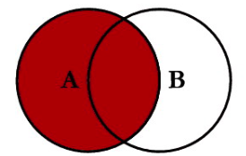

```r
left_join(data_A,data_B,by="country")
```

```
   country Var1   Var2
1  Nigeria    4    Low
2  England    3   <NA>
3 Botswana    6 Medium
```

### right_join

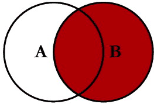

```r
right_join(data_A,data_B,by="country")
```

```
        country Var1   Var2
1       Nigeria    4    Low
2 United States   NA   High
3      Botswana    6 Medium
```

### inner_join

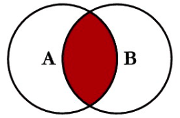

```r
inner_join(data_A,data_B,by="country")
```

```
   country Var1   Var2
1  Nigeria    4    Low
2 Botswana    6 Medium
```

### full_join

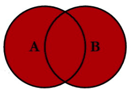

```r
full_join(data_A,data_B,by="country")
```

```
        country Var1   Var2
1       Nigeria    4    Low
2       England    3   <NA>
3      Botswana    6 Medium
4 United States   NA   High
```

### anti_join (left)

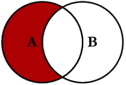

```r
anti_join(data_A,data_B,by="country")
```

```
  country Var1
1 England    3
```

### anti_join (right)

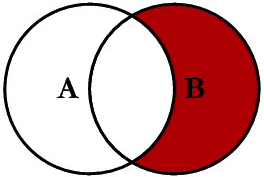

```r
anti_join(data_B,data_A,by="country")
```

```
        country Var2
1 United States High
```

### Bind Rows

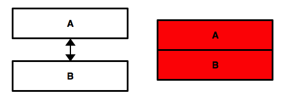

```r
bind_rows(data_A,data_B)
```

```
        country Var1   Var2
1       Nigeria    4   <NA>
2       England    3   <NA>
3      Botswana    6   <NA>
4       Nigeria   NA    Low
5 United States   NA   High
6      Botswana   NA Medium
```

### Bind Columns

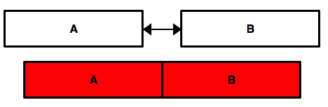

```r
bind_cols(data_A,data_B)
```

```
   country Var1      country1   Var2
1  Nigeria    4       Nigeria    Low
2  England    3 United States   High
3 Botswana    6      Botswana Medium
```

### Disparate column names

Sometimes the naming conventions of two datasets don't perfectly align. When this happens, we can specify how data merges onto one another more explicitly using the `by=` argument.

Moreover, we can merge on *more* than one dimension by specifying all relevant column names.

### Disparate column names

Once again, consider the following example data..

```r
data_A
```

```
   country year Var1
1  Nigeria 1999    4
2  England 2001    3
3 Botswana 2000    6
```

```r
data_B
```

```
   country_name year   Var2
1       Nigeria 1999    Low
2 United States 2004   High
3      Botswana 2003 Medium
```

### Disparate column names

```r
full_join(data_A,data_B,
          by=c('country'='country_name',
               'year'))
```

```
        country year Var1   Var2
1       Nigeria 1999    4    Low
2       England 2001    3   <NA>
3      Botswana 2000    6   <NA>
4 United States 2004   NA   High
5      Botswana 2003   NA Medium
```

## Manipulating Data

### dplyr

There are many different ways to perform the same task in `R`, and some are easier than others. Ultimately, what we are concerned with is **producing results quickly, effectively, and reliably**.

The `dplyr` package (part of the `tidyverse`) offers an intuitive **verb based** approach to data management in `R`. The goal of the `dplyr` logic is to provide an easy, intuitive naming convention for ubiquitous to data management tasks.

> Note that the tidyverse moves to a `tibble` data.frame, which is a special kind of data.frame class that keeps the best parts of `data.frame` but drops the unnecessary bits, such as printing the entire data object.

### Key dplyr functions

Let's review the following set of functions:

- `select()`
- `arrange()`
- `filter()`
- `mutate()`
- `transmute()`
- `summarize()`
- `group_by()`
- `recode()`
- `tally()`

To walk through the performance of each function, we'll use an internal dataset called `presidential`.

```r
?presidential # for information on the data
```

```r
dat <- presidential
head(dat)
```

```
# A tibble: 6 x 4
        name      start        end      party
       <chr>     <date>     <date>      <chr>
1 Eisenhower 1953-01-20 1961-01-20 Republican
2    Kennedy 1961-01-20 1963-11-22 Democratic
3    Johnson 1963-11-22 1969-01-20 Democratic
4      Nixon 1969-01-20 1974-08-09 Republican
5       Ford 1974-08-09 1977-01-20 Republican
6     Carter 1977-01-20 1981-01-20 Democratic
```

### select()

With `select()` we can quickly subset our data by each variable name.

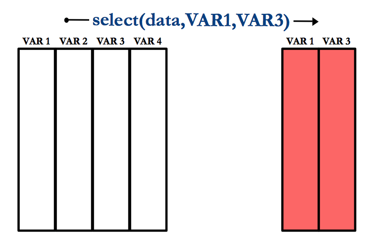

### select()

```r
select(dat,name,party)
```

```
# A tibble: 11 x 2
         name      party
        <chr>      <chr>
 1 Eisenhower Republican
 2    Kennedy Democratic
 3    Johnson Democratic
 4      Nixon Republican
 5       Ford Republican
 6     Carter Democratic
 7     Reagan Republican
 8       Bush Republican
 9    Clinton Democratic
10       Bush Republican
11      Obama Democratic
```

```r
select(dat,name:end)
```

```
# A tibble: 11 x 3
         name      start        end
        <chr>     <date>     <date>
 1 Eisenhower 1953-01-20 1961-01-20
 2    Kennedy 1961-01-20 1963-11-22
 3    Johnson 1963-11-22 1969-01-20
 4      Nixon 1969-01-20 1974-08-09
 5       Ford 1974-08-09 1977-01-20
 6     Carter 1977-01-20 1981-01-20
 7     Reagan 1981-01-20 1989-01-20
 8       Bush 1989-01-20 1993-01-20
 9    Clinton 1993-01-20 2001-01-20
10       Bush 2001-01-20 2009-01-20
11      Obama 2009-01-20 2017-01-20
```

The **order** in which variables are selected will translate to the output. Thus, one can easily **reorder columns** with `select()`.

```r
select(dat,name,party,start,end)
```

```
# A tibble: 11 x 4
         name      party      start        end
        <chr>      <chr>     <date>     <date>
 1 Eisenhower Republican 1953-01-20 1961-01-20
 2    Kennedy Democratic 1961-01-20 1963-11-22
 3    Johnson Democratic 1963-11-22 1969-01-20
 4      Nixon Republican 1969-01-20 1974-08-09
 5       Ford Republican 1974-08-09 1977-01-20
 6     Carter Democratic 1977-01-20 1981-01-20
 7     Reagan Republican 1981-01-20 1989-01-20
 8       Bush Republican 1989-01-20 1993-01-20
 9    Clinton Democratic 1993-01-20 2001-01-20
10       Bush Republican 2001-01-20 2009-01-20
11      Obama Democratic 2009-01-20 2017-01-20
```

We can also easily **rename** variables by simply providing a new name within the function.

```r
select(dat,president=name,
       startdate=start,
       enddate=end,party)
```

```
# A tibble: 11 x 4
    president  startdate    enddate      party
        <chr>     <date>     <date>      <chr>
 1 Eisenhower 1953-01-20 1961-01-20 Republican
 2    Kennedy 1961-01-20 1963-11-22 Democratic
 3    Johnson 1963-11-22 1969-01-20 Democratic
 4      Nixon 1969-01-20 1974-08-09 Republican
 5       Ford 1974-08-09 1977-01-20 Republican
 6     Carter 1977-01-20 1981-01-20 Democratic
 7     Reagan 1981-01-20 1989-01-20 Republican
 8       Bush 1989-01-20 1993-01-20 Republican
 9    Clinton 1993-01-20 2001-01-20 Democratic
10       Bush 2001-01-20 2009-01-20 Republican
11      Obama 2009-01-20 2017-01-20 Democratic
```

Lastly, `select()` offers us a convenient way to drop variables by using the same logic that we employed with putting a **negative sign** in front of a dimension. The only difference here is that we can do the same but with a variable name.

Here we **drop** the `start` date variable.

```r
select(dat,-start)
```

```
# A tibble: 11 x 3
         name        end      party
        <chr>     <date>      <chr>
 1 Eisenhower 1961-01-20 Republican
 2    Kennedy 1963-11-22 Democratic
 3    Johnson 1969-01-20 Democratic
 4      Nixon 1974-08-09 Republican
 5       Ford 1977-01-20 Republican
 6     Carter 1981-01-20 Democratic
 7     Reagan 1989-01-20 Republican
 8       Bush 1993-01-20 Republican
 9    Clinton 2001-01-20 Democratic
10       Bush 2009-01-20 Republican
11      Obama 2017-01-20 Democratic
```

### arrange()

With `arrange()`, we can quickly **order** data by a variable.

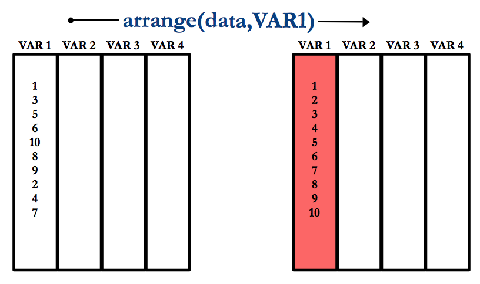

```r
arrange(dat,party)
```

```
# A tibble: 11 x 4
         name      start        end      party
        <chr>     <date>     <date>      <chr>
 1    Kennedy 1961-01-20 1963-11-22 Democratic
 2    Johnson 1963-11-22 1969-01-20 Democratic
 3     Carter 1977-01-20 1981-01-20 Democratic
 4    Clinton 1993-01-20 2001-01-20 Democratic
 5      Obama 2009-01-20 2017-01-20 Democratic
 6 Eisenhower 1953-01-20 1961-01-20 Republican
 7      Nixon 1969-01-20 1974-08-09 Republican
 8       Ford 1974-08-09 1977-01-20 Republican
 9     Reagan 1981-01-20 1989-01-20 Republican
10       Bush 1989-01-20 1993-01-20 Republican
11       Bush 2001-01-20 2009-01-20 Republican
```

`arrange()` with the internal function `desc()` can change to a **descending** ordering.

```r
arrange(dat,desc(start))
```

```
# A tibble: 11 x 4
         name      start        end      party
        <chr>     <date>     <date>      <chr>
 1      Obama 2009-01-20 2017-01-20 Democratic
 2       Bush 2001-01-20 2009-01-20 Republican
 3    Clinton 1993-01-20 2001-01-20 Democratic
 4       Bush 1989-01-20 1993-01-20 Republican
 5     Reagan 1981-01-20 1989-01-20 Republican
 6     Carter 1977-01-20 1981-01-20 Democratic
 7       Ford 1974-08-09 1977-01-20 Republican
 8      Nixon 1969-01-20 1974-08-09 Republican
 9    Johnson 1963-11-22 1969-01-20 Democratic
10    Kennedy 1961-01-20 1963-11-22 Democratic
11 Eisenhower 1953-01-20 1961-01-20 Republican
```

### filter()

`filter()` offers a quick way to **subset** data by some **conditional statement**.

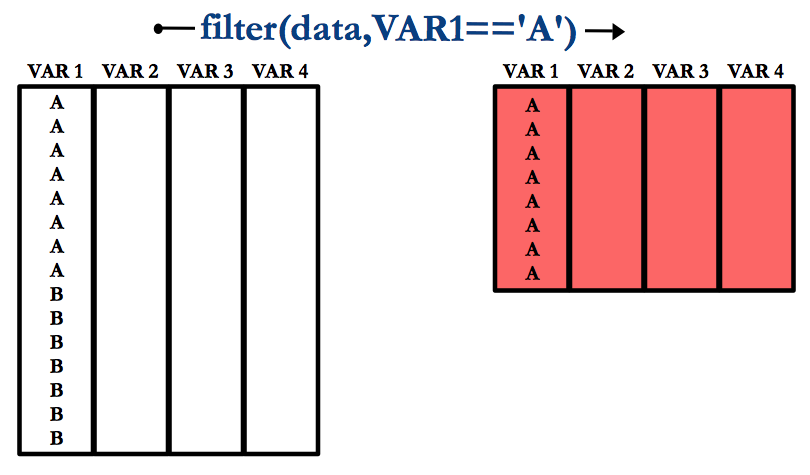

### filter()

```r
filter(dat,party == "Republican")
```

```
# A tibble: 6 x 4
        name      start        end      party
       <chr>     <date>     <date>      <chr>
1 Eisenhower 1953-01-20 1961-01-20 Republican
2      Nixon 1969-01-20 1974-08-09 Republican
3       Ford 1974-08-09 1977-01-20 Republican
4     Reagan 1981-01-20 1989-01-20 Republican
5       Bush 1989-01-20 1993-01-20 Republican
6       Bush 2001-01-20 2009-01-20 Republican
```

### mutate()

`mutate()` provides us a way to quickly **generate a new variable**.

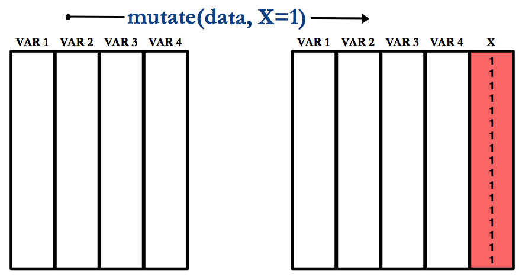

```r
x <- select(dat,name,start,end)
mutate(x,
       # in office during cold war
       CW = start <= '1990-03-11')
```

```
# A tibble: 11 x 4
         name      start        end    CW
        <chr>     <date>     <date> <lgl>
 1 Eisenhower 1953-01-20 1961-01-20  TRUE
 2    Kennedy 1961-01-20 1963-11-22  TRUE
 3    Johnson 1963-11-22 1969-01-20  TRUE
 4      Nixon 1969-01-20 1974-08-09  TRUE
 5       Ford 1974-08-09 1977-01-20  TRUE
 6     Carter 1977-01-20 1981-01-20  TRUE
 7     Reagan 1981-01-20 1989-01-20  TRUE
 8       Bush 1989-01-20 1993-01-20  TRUE
 9    Clinton 1993-01-20 2001-01-20 FALSE
10       Bush 2001-01-20 2009-01-20 FALSE
11      Obama 2009-01-20 2017-01-20 FALSE
```

`mutate()` also allows us to *instantly* use variables we just created.

```r
x <- select(dat,name,start,end)
mutate(x,
       CW = start <= '1990-03-11',
       CW = as.numeric(CW))
```

```
# A tibble: 11 x 4
         name      start        end    CW
        <chr>     <date>     <date> <dbl>
 1 Eisenhower 1953-01-20 1961-01-20     1
 2    Kennedy 1961-01-20 1963-11-22     1
 3    Johnson 1963-11-22 1969-01-20     1
 4      Nixon 1969-01-20 1974-08-09     1
 5       Ford 1974-08-09 1977-01-20     1
 6     Carter 1977-01-20 1981-01-20     1
 7     Reagan 1981-01-20 1989-01-20     1
 8       Bush 1989-01-20 1993-01-20     1
 9    Clinton 1993-01-20 2001-01-20     0
10       Bush 2001-01-20 2009-01-20     0
11      Obama 2009-01-20 2017-01-20     0
```

### transmute()

Like `mutate()`, `transmute()` provides a method for generating a new variable, but unlike the former, it **returns only the newly created variable**.

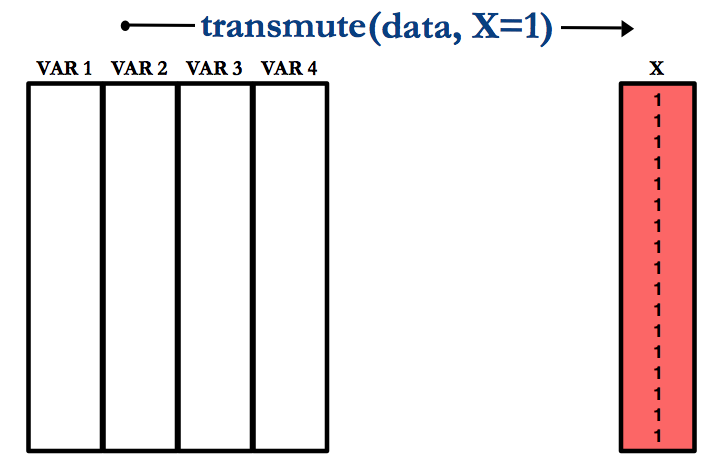

```r
transmute(dat,CW = start <= '1990-03-11')
```

```
# A tibble: 11 x 1
      CW
   <lgl>
 1  TRUE
 2  TRUE
 3  TRUE
 4  TRUE
 5  TRUE
 6  TRUE
 7  TRUE
 8  TRUE
 9 FALSE
10 FALSE
11 FALSE
```

### summarize()

`summarize()` offers a quick way of summarizing a variable by some function.

```r
# Group the data by species
summarize(dat,
          days_in_office = mean(end-start),
          max = max(end-start),
          min = min(end-start))
```

```
# A tibble: 1 x 3
  days_in_office       max      min
          <time>    <time>   <time>
1  2125.091 days 2922 days 895 days
```

There are a number of internal functions that can be used with `mutate()`, `transmute()`, and `summarize()`.

- `n()` ::: counts the number of observations
- `distinct()` ::: returns the number of unique entries
- `n_distinct()` ::: counts the number of distinct entries

```r
summarize(dat,N=n(),N_party=n_distinct(party))
```

```
# A tibble: 1 x 2
      N N_party
  <int>   <int>
1    11       2
```

### group_by()

`group_by()` offers a way to cluster the data by a specific variable.

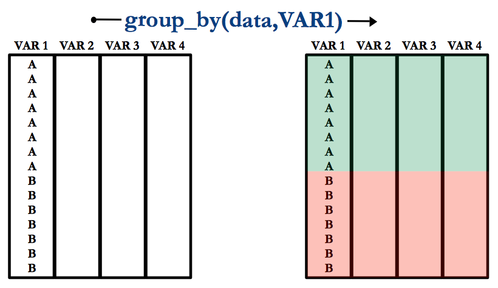

When used in conjunction with some of the other functions, `group_by()` becomes a powerful **clustering function**.

```r
x <- group_by(dat,party) # group by party
summarize(x,
          min_days_in_office = min(end-start))
```

```
# A tibble: 2 x 2
       party min_days_in_office
       <chr>             <time>
1 Democratic          1036 days
2 Republican           895 days
```

### recode()

`recode()` allows you to quickly **recode a variable** (though conditional statements prove to be the most efficient way to do this)

```r
mutate(dat,
       party = recode(party,
                      'Republican'=1,
                      'Democratic'=0))
```

```
# A tibble: 11 x 4
         name      start        end party
        <chr>     <date>     <date> <dbl>
 1 Eisenhower 1953-01-20 1961-01-20     1
 2    Kennedy 1961-01-20 1963-11-22     0
 3    Johnson 1963-11-22 1969-01-20     0
 4      Nixon 1969-01-20 1974-08-09     1
 5       Ford 1974-08-09 1977-01-20     1
 6     Carter 1977-01-20 1981-01-20     0
 7     Reagan 1981-01-20 1989-01-20     1
 8       Bush 1989-01-20 1993-01-20     1
 9    Clinton 1993-01-20 2001-01-20     0
10       Bush 2001-01-20 2009-01-20     1
11      Obama 2009-01-20 2017-01-20     0
```

### tally()

`tally()` offers quick counts of a variable which can be quite useful when used alongside some of the other functions.

Here we are seeing how many observations we have *by group*.

```r
x <- group_by(dat,party)
tally(x)
```

```
# A tibble: 2 x 2
       party     n
       <chr> <int>
1 Democratic     5
2 Republican     6
```

### Combining Functions

When we need to do a series of manipulations, we can **perform each manipulation individually and save each entry as a new object** that we write over.

```r
x <- filter(dat,party=='Republican')
x <- group_by(x,name)
x <- transmute(x,t_in_office = end-start)
x <- arrange(x,t_in_office)
x
```

```
# A tibble: 6 x 2
# Groups:   name [5]
        name t_in_office
       <chr>      <time>
1       Ford    895 days
2       Bush   1461 days
3      Nixon   2027 days
4 Eisenhower   2922 days
5     Reagan   2922 days
6       Bush   2922 days
```

### Nesting Functions

Or we can **nest** functions *within* each other.

```r
arrange(
  transmute(
    group_by(
      filter(dat,party=='Republican'),
      name),
    t_in_office = end-start),
  t_in_office)
```

```
# A tibble: 6 x 2
# Groups:   name [5]
        name t_in_office
       <chr>      <time>
1       Ford    895 days
2       Bush   1461 days
3      Nixon   2027 days
4 Eisenhower   2922 days
5     Reagan   2922 days
6       Bush   2922 days
```

### Nesting Functions

> The issue with **nesting functions** is that it is difficult to detect a mistake!

### Piping Functions

The **PIPE** is a useful tool that allows us to **pass** output from one function to the next.

To pipe we write `%>%` *in-between* each function.

```
function1() %>% function2()
```

Piping offers is a clean way of manipulating data that is **intuitive and easy to read**.

Here we **pass** our `data` to `filter()` then to `group_by()` then to `transmute()` and then finally to `arrange()` which returns our output!

```r
dat %>% filter(party=='Republican') %>%
  group_by(name) %>%
  transmute(t_in_office = end-start) %>%
  arrange(t_in_office)
```

```
# A tibble: 6 x 2
# Groups:   name [5]
        name t_in_office
       <chr>      <time>
1       Ford    895 days
2       Bush   1461 days
3      Nixon   2027 days
4 Eisenhower   2922 days
5     Reagan   2922 days
6       Bush   2922 days
```

### Two things to keep in mind when piping...

1. Functions *must* be linked with `%>%`
2. When functions have **multiple arguments**, point to where the data should go with a period (`.`)

```r
data %>% function(arg1= ., arg2=TRUE)
```

### More dplyr functions...

We've only covered a few functions here. Here are some more…

- `sample_n()` - Grab an N random sample of your data
- `sample_frac()` - Grab a random sample that is some fraction of your total data
- `top_n()` - get the top N number of entries from a data frame
- `slice()` - grab specific row ranges
- `glimpse()` - quickly preview the data

## Visualizing Data

### ggplot2

`ggplot2` (a part of the `tidyverse` package) is a power graphics package that offers a flexible and intuitive graphics language capable of building sophisticated graphics.

`ggplots` have a special syntax that we'll have to get use to, but once we understand the basics, we'll be able to produce some advanced and sophisticated graphics

### Logic of the ggplot2 package

`ggplot2` is based on a “**grammar of graphics**”. In essence, you can build every graph from the same components:

- a data set,
- a coordinate system,
- geoms.

`ggplot2`s flexibility emerges from these **easy step-by-step builds**, where data is converted to a coordinate plan, and secondary features, such as groupings, size, and color, can be easily added to the data as an additional dimension.

### Example Data

For the following examples, let's use the `diamonds` data, which is an example dataset provided by ggplot that contains the prices and other attributes of almost 54,000 diamonds.

```r
dim(diamonds)
```

```
[1] 53940    10
```

```r
colnames(diamonds)
```

```
 [1] "carat"   "cut"     "color"   "clarity" "depth"   "table"   "price"
 [8] "x"       "y"       "z"
```

### ggplot()

The `ggplot()` object acts as a storage facility for the data. It is here where we define the data frame that houses the x and y coordinate values themselves and instructions on how to split the data.

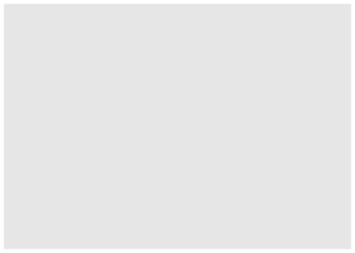

```r
ggplot(data=diamonds)
```

### aes()

As we can see there is nothing in the frame since we have not added any layers. We need to specify which variables we are using with the `aes()` “Aesthetics” argument.

The `aes()` aesthetic mapping function lives inside a ggplot object and is where we specify the set of plot attributes that remain constant throughout the subsequent layers

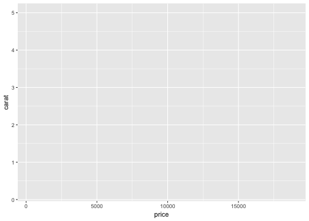

```r
ggplot(data=diamonds,aes(x=price,y=carat))
```

We have the variables on both axises but still no graphical output. We must tell `gglot` what we want the data to be presented as using a `geom` function.

We use the `+` operator to append `geom` layers onto a `ggplot` object. This way we can build on a plot sequentially by *adding* layers.

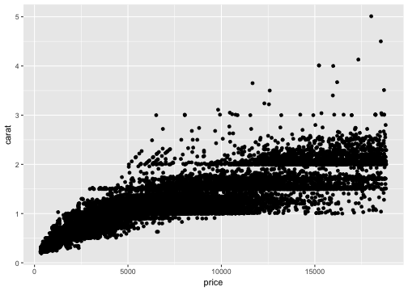

```r
ggplot(data=diamonds,aes(x=price,y=carat)) +
  geom_point() # adding a points layer
```

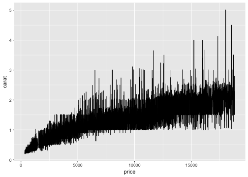

```r
ggplot(data=diamonds,aes(x=price,y=carat)) +
  geom_line() # adding a points layer
```

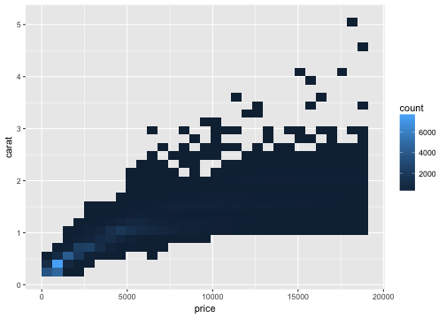

```r
ggplot(data=diamonds,aes(x=price,y=carat)) +
  geom_bin2d() # adding a bin layer
```

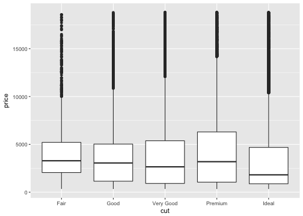

```r
ggplot(data=diamonds,aes(x=cut,y=price)) +
  geom_boxplot() # box plot layer
```

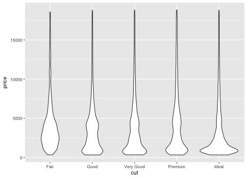

```r
ggplot(data=diamonds,aes(x=cut,y=price)) +
  geom_violin() # violin plot layer
```

There are also a number of useful **univariate** geoms available.

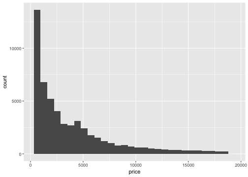

```r
ggplot(data=diamonds,aes(x=price)) +
  geom_histogram() # histogram layer
```

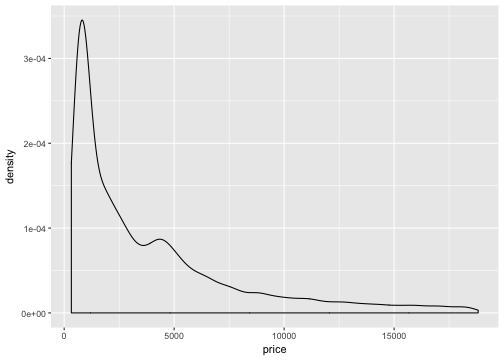

```r
ggplot(data=diamonds,aes(x=price)) +
  geom_density() # density layer
```

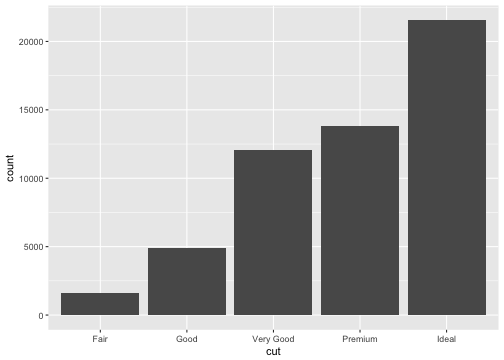

```r
ggplot(data=diamonds,aes(x=cut)) +
  geom_bar() # bar plot layer
```

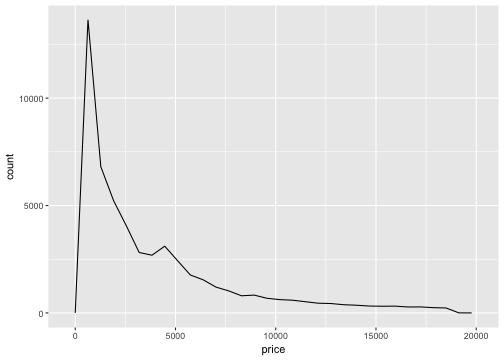

```r
ggplot(data=diamonds,aes(x=price)) +
  geom_freqpoly() # frequency plot layer
```